# Test a Perceptual Phenomenon

### Analyzing the Stroop Effect

Perform the analysis in the space below. Remember to follow [the instructions](https://docs.google.com/document/d/1-OkpZLjG_kX9J6LIQ5IltsqMzVWjh36QpnP2RYpVdPU/pub?embedded=True) and review the [project rubric](https://review.udacity.com/#!/rubrics/71/view) before submitting. Once you've completed the analysis and write-up, download this file as a PDF or HTML file, upload that PDF/HTML into the workspace here (click on the orange Jupyter icon in the upper left then Upload), then use the Submit Project button at the bottom of this page. This will create a zip file containing both this .ipynb doc and the PDF/HTML doc that will be submitted for your project.

(1) What is the independent variable? What is the dependent variable?

> - Dependent Variable : The time (in seconds) it took each participant to read the list.
> - Independent Variable: The condition in which the words were printed.

(2) What is an appropriate set of hypotheses for this task? Specify your null and alternative hypotheses, and clearly define any notation used. Justify your choices.

> - $H_{0}$ Null Hypotheses: There is no difference between the Incongruent mean (μ) and Congruent mean (μ).
> - $H_{1}$ Alternative Hypotheses: There is a difference between Incongruent and Congruent means(μ).

$H_{0}$: $μ_{incongruent}$ - $μ_{congruent}$ = 0

$H_{1}$: $μ_{incongruent}$ - $μ_{congruent}$ ≠ 0

alpha = 0.05

(3) Report some descriptive statistics regarding this dataset. Include at least one measure of central tendency and at least one measure of variability. The name of the data file is 'stroopdata.csv'.

```python
# Perform the analysis here
import pandas as pd
import numpy as np
import matplotlib.pyplot as plt
import random
from scipy import stats
%matplotlib inline
```

```python
df = pd.read_csv('stroopdata.csv')
df.head()
```

|  | Congruent | Incongruent |
| --- | --- | --- |
| 0 | 12.079 | 19.278 |
| 1 | 16.791 | 18.741 |
| 2 | 9.564 | 21.214 |
| 3 | 8.630 | 15.687 |
| 4 | 14.669 | 22.803 |

```python
df.describe()
```

|  | Congruent | Incongruent |
| --- | --- | --- |
| count | 24.000000 | 24.000000 |
| mean | 14.051125 | 22.015917 |
| std | 3.559358 | 4.797057 |
| min | 8.630000 | 15.687000 |
| 25% | 11.895250 | 18.716750 |
| 50% | 14.356500 | 21.017500 |
| 75% | 16.200750 | 24.051500 |
| max | 22.328000 | 35.255000 |

```python
obs_diff = df['Incongruent'].mean()-df['Congruent'].mean()
obs_diff
```

```
7.964791666666665
```

> The mean time for the Congruent condition is 14.05 while the mean time for the Incongruent condition was 22.01 seconds. Based on this descriptive analysis, we can see a difference of 7.9 seconds between the two conditions.

(4) Provide one or two visualizations that show the distribution of the sample data. Write one or two sentences noting what you observe about the plot or plots.

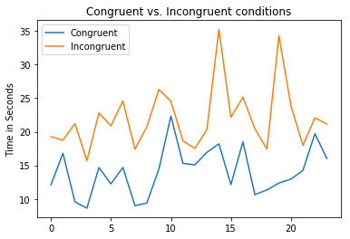

```python
plt.plot(df);
plt.legend(('Congruent', 'Incongruent'));
plt.ylabel('Time in Seconds');
plt.title('Congruent vs. Incongruent conditions');
#plt.figure(figsize=(10,15));
```

> As we can see in the line graphs above, there is a noticable difference in the time it took participants with the Congruent condition and Incongruent conditions.

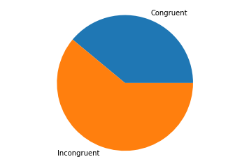

```python
cong_mean = df['Congruent'].mean()
incong_mean = df['Incongruent'].mean()
means = [cong_mean, incong_mean]
labels = ['Congruent','Incongruent']
plt.pie(means, labels=labels);
plt.axis('equal');
figsize=(10,6)
```

> The pie chart above shows the mean difference of the time for Congruent and Incongruent conditions. There is a noticable difference between the two conditions.

> To get an overall observation of the distribution of the dataset, we will represent both columns in the boxplot forms:

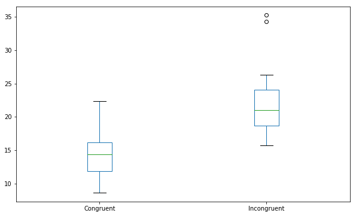

```python
df[['Congruent', 'Incongruent']].plot(kind='box', figsize=(10,6));
```

> As you can see, the distribution(mean, median, max...) for the Incongruent condition is different than for the Congruent Condition. You could also notice that there are two outliers for the Incongruent group, but won't affect our calculations.

(5) Now, perform the statistical test and report your results. What is your confidence level or Type I error associated with your test? What is your conclusion regarding the hypotheses you set up? Did the results match up with your expectations? **Hint:** Think about what is being measured on each individual, and what statistic best captures how an individual reacts in each environment.

> Since the population size is only 24, we are going to perform a t-test. In addition, we will be using the dependent t-test(scipy's ttest_rel function) to have an accurate result because our participants were the same for both conditions.

> We choose the t-test under the following assumtions:
> - Our data is normally distributed
> - Our sampling is random.
> - The differences are of measurement variables.

```python
t, p = stats.ttest_rel(df['Incongruent'], df['Congruent'])
```

```python
print("T statistics score = {} and p-value = {}".format(t,p))
```

```
T statistics score = 8.020706944109957 and p-value = 4.103000585711178e-08
```

(6) Optional: What do you think is responsible for the effects observed? Can you think of an alternative or similar task that would result in a similar effect? Some research about the problem will be helpful for thinking about these two questions!

> To interact in the world and comprehend things, we need to understand things first. Visual processing is one of part of the understanding, and is composed of several parts. When we see an object, we don't just see it's physical attributes, we also comprehend the meaning behind it.  
> According to a paper published by Washington University, there are two theories that could cause the stroop effect. Fisrt, the Speed of Processing Theory, and Selective Attention Theory.
> - Speed of Processing Theory states that words are read faster than colors are named
> - Seletive Attention Theory states that name colors require more attention than reading words.

Reference:

```
- https://statistics.laerd.com/statistical-guides/dependent-t-test-statistical-guide.php
- https://faculty.washington.edu/chudler/words.html
- http://influentialpoints.com/Training/paired_t-test-principles-properties-assumptions.htm
```